# BMMB 521: Data analysis in R

17 March 2026

# 1 Background

The goal of this session is to give you a quick intro into how to explore and visualize ’omics data. We will be building off down-sampled data collected as part of Tian et al. Cell Host & Microbe 2025. In short, this data is derived from microbiome sequencing data of healthy individuals and those who are colonized with *C. difficile*.

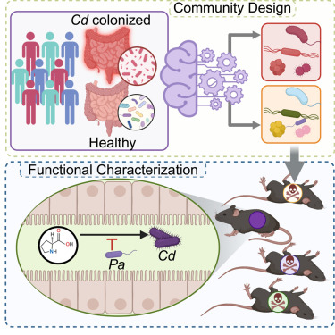

# 2 Preparing For Class

Before our session, please complete the sections below. The goal is for you to have downloaded all of the data and software ahead of time so we can focus on concepts and data interpretation rather than troubleshooting. That being said… installing software is often the most difficult part of bioinformatics, so please email `jordan.bisanz@psu.edu` if you run into difficulties. You will need access to a mac/windows/Linux machine with at least ~100 MB of free storage. If you can’t access a computer, please let me know ahead of time and I can make an arrangement for you to remotely access a R studio session via your web browser.

## 2.1 Installing R and R Studio

We will be making use of the R programming language which is commonly used across many fields for statistical analysis. To begin, please install and/or update to version of R (4.5.2 by downloading from the following [link](https://cran.rstudio.com/). R is commonly accessed through an easy-to-use interface called R studio. Please downloaded [here](https://posit.co/download/rstudio-desktop/). R and many of the packages you would use for data analysis are updated on a regular basis, **please ensure you have the latest version of R.**

If you are not familiar with R, it is an extremely useful tool for analyzing and visualizing data. If you are not familiar with it, please watch these videos before our class:

- [Introduction to R Programming with Data Camp](https://www.youtube.com/watch?v=HkNFn6eosaU)
- [Getting started with R and RStudio](https://www.youtube.com/watch?v=lVKMsaWju8w&t=3s)
- If you are interested in learning more R, I recommend [this book](https://www.amazon.com/Data-Science-Transform-Visualize-Model/dp/1491910399/ref=sr_1_9?dchild=1&keywords=tidyverse&qid=1620329413&s=books&sr=1-9).

To ensure you have successfully installed the software, please open R studio and type the following code into your console:

```r
R.Version()$version.string
```

The expected output that should be reported is: `R version 4.5.2 (2025-10-31)`.

## 2.2 Installing Required Packages

Generally speaking, most packages for bioinformatics exist in 3 places: CRAN, Bioconductor, and Github. CRAN is the main R repository from which packages can be installed using `install.packages()`. Bioconductor is a repository specializing in bioinformatics. Bioconductor packages are installed via its own package (available from CRAN) called BiocManager which has a function called `BiocManager::install()`. Finally, the newest versions of packages or in-development packages are often found on github which can be installed using a package called devtools which offers `devtools::install_github()`. To install the required packages, copy and past the code below line by line into your R session. If asked to compile type `yes` and if asked to update packages types `no`.

```r
install.packages("tidyverse") # A group of related packages to facilitate a wide variety of useful tasks including plotting

install.packages("devtools") # A multi-purpose tool for developing and installing packages
install.packages("BiocManager") # The package manager for Bioconductor

install.packages("vegan") # A commonly used ecology package offering diversity calculations and statistical tests
install.packages("ape") # A package for phylogenetic analysis offering several useful functions for microbial ecology

devtools::install_github("jbisanz/qiime2R") # A multi-purpose microbiome import/processing package written by yours truly. This will also isntall a number of other pre-requisit packages.

install.packages("caret")
install.packages("randomForest")
```

After you have installed all of the above packages, it is a good idea to try loading them one by one as below. If a package fails to load, read the error message and then try to reinstall. If still having issues please run past your favorite LLM for assistance. Please contact me if there are issues which you can’t resolve.

```r
library(tidyverse)
library(readxl) #part of the tidyverse for reading excel files
library(ape)
library(vegan)
library(qiime2R)
library(caret)
library(randomForest)
```

## 2.3 Downloading Data

We will start by creating a new directory for our project using the `dir.create()` function. I am going to place this on my desktop, but you might want to pick somewhere else depending on your computer.

```r
dir.create("~/Desktop/BMMB521_tutorial") #Note: windows users would use dir.create("C:\\Users\\YourUserName\\Desktop\\BMMB521_tutorial")
```

Then we can specifically set our working directory to be inside this older as below:

```r
setwd("~/Desktop/BMMB521_tutorial") #Note: windows users would use setwd("C:\\Users\\YourUserName\\Desktop\\BMMB521_tutorial")
```

### 2.3.1 Feature Abundances

In this case we will be using data which has already been processed. We will download a table of genus-summarized microbial abundances where each column is a sample, and each row is a genus. The values represent the number of reads (counts) assigned to each genus on a per-sample basis.

Let us download it as below:

```r
dir.create("data")
download.file("https://github.com/BisanzLab/BMMB521_SP26/raw/refs/heads/main/data/Genus_Abundances.tsv","data/Genus_Abundances.tsv")
```

### 2.3.2 Metadata

Having the data is great, but unless we know what it is, it is pretty useless. This is called metadata, and a spreadsheet (in tab separated format) is available to download as below. Note that you could just as easily use excel spreadsheets; however, there are some special considerations for reading/writing excel files and they love to auto-convert text to dates which can cause issues.

```r
download.file("https://github.com/BisanzLab/BMMB521_SP26/raw/refs/heads/main/data/Metadata.tsv","data/Metadata.tsv")
```

After all of this, you should find a folder on your desktop called `BMMB521_tutorial`. Within this folder, you should find a sub folder called data containing two files: your Metadata.tsv file, and the Genus_Abundances.tsv file. With these and the packages installed, you are ready to begin!

Stop here before class!